# Analiza Wielowymiarowa

Ewelina Nieć

2024-03-23

Projekt ten skupia się na analizie wielowymiarowej w kontekście rynku finansowego. Celem jest zastosowanie modelu SUR (Seemingly Unrelated Regressions) do analizy stóp zwrotu branżowych portfeli inwestycyjnych.

**Uwaga:** Przyjęty poziom istotności wynosi α = 5%.

## Wczytywanie danych

Najpierw dokonano wczytania danych dotyczących stóp zwrotu różnych branżowych portfeli inwestycyjnych, stopy zwrotu portfela rynkowego (WIGu) oraz stopy wolnej od ryzyka. Dane te są zaprezentowane w formie tabeli.

```r
wig <- read_csv("Dane/wig_m.csv")
wig <- wig[,c(1,5)]
colnames(wig) <- c('data','wig')

wig_banki <- read_csv("Dane/wig_banki_m.csv")
wig_banki <- wig_banki[,5]
colnames(wig_banki) <- c('wig_banki')

wig_budow <- read_csv("Dane/wig_budow_m.csv")
wig_budow <- wig_budow[,5]
colnames(wig_budow) <- c('wig_budow')

wig_chemia <- read_csv("Dane/wig_chemia_m.csv")
wig_chemia <- wig_chemia[,5]
colnames(wig_chemia) <- c('wig_chemia')

wig_energia <- read_csv("Dane/wig_energ_m.csv")
wig_energia <- wig_energia[,5]
colnames(wig_energia) <- c('wig_energia')

wig_gornic <- read_csv("Dane/wig_gornic_m.csv")
wig_gornic <- wig_gornic[,5]
colnames(wig_gornic) <- c('wig_gornic')

wig_gry <- read_csv("Dane/wig_gry_m.csv")
wig_gry <- wig_gry[,5]
colnames(wig_gry) <- c('wig_gry')

wig_info <- read_csv("Dane/wig_info_m.csv")
wig_info <- wig_info[,5]
colnames(wig_info) <- c('wig_info')

wig_leki <- read_csv("Dane/wig_leki_m.csv")
wig_leki <- wig_leki[,5]
colnames(wig_leki) <- c('wig_leki')

wig_media <- read_csv("Dane/wig_media_m.csv")
wig_media <- wig_media[,5]
colnames(wig_media) <- c('wig_media')

wig_moto <- read_csv("Dane/wig_moto_m.csv")
wig_moto <- wig_moto[,5]
colnames(wig_moto) <- c('wig_moto')

wig_nrchom <- read_csv("Dane/wig_nrchom_m.csv")
wig_nrchom <- wig_nrchom[,5]
colnames(wig_nrchom) <- c('wig_nrchom')

wig_odziez <- read_csv("Dane/wig_odziez_m.csv")
wig_odziez <- wig_odziez[,5]
colnames(wig_odziez) <- c('wig_odziez')

wig_paliwa <- read_csv("Dane/wig_paliwa_m.csv")
wig_paliwa <- wig_paliwa[,5]
colnames(wig_paliwa) <- c('wig_paliwa')

wig_spozyw <- read_csv("Dane/wig_spozyw_m.csv")
wig_spozyw <- wig_spozyw[,5]
colnames(wig_spozyw) <- c('wig_spozyw')

stopa_wolna <- read_csv("Dane/10yply_b_m.csv")
stopa_wolna <- stopa_wolna[,5]/100
colnames(stopa_wolna) <- c('stopa_wolna')

dane <- data.frame(wig,wig_banki,wig_budow,wig_chemia,
                   wig_energia,wig_gornic,wig_gry,wig_info,
                   wig_leki,wig_media,wig_moto,wig_nrchom,
                   wig_odziez,wig_paliwa,wig_spozyw,stopa_wolna/12)

knitr::kable(head(dane), align = "cccccccc")
```

| data | wig | wig_banki | wig_budow | wig_chemia | wig_energia | wig_gornic | wig_gry | wig_info | wig_leki | wig_media | wig_moto | wig_nrchom | wig_odziez | wig_paliwa | wig_spozyw | stopa_wolna |
| --- | --- | --- | --- | --- | --- | --- | --- | --- | --- | --- | --- | --- | --- | --- | --- | --- |
| 2017-01-31 | 55232.32 | 6839.04 | 3158.51 | 16201.95 | 2680.31 | 4394.62 | 5723.09 | 2278.96 | 5856.80 | 4857.26 | 5555.74 | 1898.52 | 4931.00 | 5436.53 | 4918.65 | 0.0032267 |
| 2017-02-28 | 58300.37 | 7241.32 | 3411.86 | 16338.33 | 2866.11 | 4603.45 | 6794.00 | 2321.99 | 6049.59 | 5113.42 | 5677.46 | 1920.81 | 5372.66 | 6316.14 | 4891.79 | 0.0031842 |
| 2017-03-31 | 57911.31 | 6991.74 | 3518.62 | 16091.27 | 2876.20 | 4157.63 | 7122.80 | 2359.40 | 6616.42 | 5167.54 | 5457.59 | 1933.40 | 6020.58 | 6561.69 | 4577.12 | 0.0029225 |
| 2017-04-30 | 61644.56 | 7484.97 | 3625.77 | 16090.56 | 2868.07 | 4518.19 | 6441.46 | 2372.02 | 6003.52 | 5176.43 | 5549.33 | 2013.24 | 5950.56 | 7496.41 | 4611.43 | 0.0028683 |
| 2017-05-31 | 60092.07 | 7421.43 | 3382.10 | 15153.04 | 2762.75 | 3887.40 | 7323.76 | 2284.17 | 5780.35 | 5290.19 | 5950.11 | 2047.89 | 5494.40 | 6931.67 | 4594.06 | 0.0027050 |
| 2017-06-30 | 61018.36 | 7261.87 | 3470.78 | 14778.71 | 3037.52 | 4106.07 | 7917.72 | 2287.84 | 6077.31 | 5126.77 | 5764.16 | 2130.39 | 6053.31 | 7128.31 | 4473.78 | 0.0027558 |

## Stopy zwrotu

Kolejnym krokiem jest wyznaczenie stóp zwrotu dla poszczególnych portfeli, według wzoru:

$$R_l = \frac{P_t -
P_{t-1}}{P_{t-1}}$$

gdzie:

- $R_l$ - stopa zwrotu,
- $P_t$ - wartość zamknięcia indeksu w czasie t,
- $P_{t−1}$ - wartość zamknięcia indeksu w czasie t-1,

```r
stopa_zwrotu <- data.frame(matrix(0, 86, 17))
stopa_zwrotu[, 1] <- dane[, 1]
for (j in 2:17){
  for (i in 2:86)
  {
  stopa_zwrotu[i, j] <- (dane[i, j] - dane[i-1, j])/dane[i-1, j]
  }
}
names(stopa_zwrotu) <- names(dane)
rownames(stopa_zwrotu) <- NULL
stopa_zwrotu <- stopa_zwrotu[-1, ]

knitr::kable(head(stopa_zwrotu), align = "cccccccc",  digits = 3)
```

|  | data | wig | wig_banki | wig_budow | wig_chemia | wig_energia | wig_gornic | wig_gry | wig_info | wig_leki | wig_media | wig_moto | wig_nrchom | wig_odziez | wig_paliwa | wig_spozyw | stopa_wolna |
| --- | --- | --- | --- | --- | --- | --- | --- | --- | --- | --- | --- | --- | --- | --- | --- | --- | --- |
| 2 | 2017-02-28 | 0.056 | 0.059 | 0.080 | 0.008 | 0.069 | 0.048 | 0.187 | 0.019 | 0.033 | 0.053 | 0.022 | 0.012 | 0.090 | 0.162 | -0.005 | -0.013 |
| 3 | 2017-03-31 | -0.007 | -0.034 | 0.031 | -0.015 | 0.004 | -0.097 | 0.048 | 0.016 | 0.094 | 0.011 | -0.039 | 0.007 | 0.121 | 0.039 | -0.064 | -0.082 |
| 4 | 2017-04-30 | 0.064 | 0.071 | 0.030 | 0.000 | -0.003 | 0.087 | -0.096 | 0.005 | -0.093 | 0.002 | 0.017 | 0.041 | -0.012 | 0.142 | 0.007 | -0.019 |
| 5 | 2017-05-31 | -0.025 | -0.008 | -0.067 | -0.058 | -0.037 | -0.140 | 0.137 | -0.037 | -0.037 | 0.022 | 0.072 | 0.017 | -0.077 | -0.075 | -0.004 | -0.057 |
| 6 | 2017-06-30 | 0.015 | -0.021 | 0.026 | -0.025 | 0.099 | 0.056 | 0.081 | 0.002 | 0.051 | -0.031 | -0.031 | 0.040 | 0.102 | 0.028 | -0.026 | 0.019 |
| 7 | 2017-07-31 | 0.026 | 0.053 | -0.050 | 0.003 | 0.100 | 0.111 | 0.007 | -0.061 | 0.004 | 0.021 | -0.055 | -0.015 | 0.015 | 0.000 | -0.013 | 0.024 |

# Model SUR

Model SUR (Seemingly Unrelated Regressions) stanowi rozszerzenie modelu regresji liniowej, w którym uwzględnia się kilka równań regresji. Każde z tych równań posiada swoją własną zmienną zależną oraz potencjalnie różne zestawy zmiennych objaśniających. Co istotne, każde równanie jest osobnym, samodzielnym modelem regresji liniowej, które można oszacować niezależnie.

W ramach projektu został wykorzystany model CAMP (Capital Asset Pricing Model), który jest jednoczynnikowym modelem wykorzystywanym do wyceny instrumentów finansowych.

Model opisuje równanie regresji:

$$R_{it} - r_{ft} = \alpha_i +
\beta_i(R_{Mt} - r_{ft}) + \epsilon_it$$

gdzie:

$R_{it}$ - stopa zwrotu i-tego portfela w czasie t (indeksu branżowego),  
$R_{Mt}$ - stopa zwrotu portfela rynkowego (WIGu),  
$r_{ft}$ - stopa zwrotu wolna od ryzyka,  
$\alpha_i, \beta_i$ - parametry strukturalne modelu regresji,  
$\epsilon_it$ - zakłócenia losowe.

Zmiennymi w danym modelu będą stopy zwrotu pomniejszone o stopę wolną od ryzyka, dlatego takie przekształcenie zostalo wykonane

```r
zmienne <- data.frame(matrix(0, 85, 16))
names(zmienne) <- names(dane)[c(1:16)]
zmienne[, 1] <- stopa_zwrotu[, 1]

for (j in 2:16){
  for (i in 1:85)
  {
    zmienne[i, j] <- stopa_zwrotu[i, j] - stopa_zwrotu[i, 17]
  }
}

zmienne <- zmienne[, -1]
```

W modelu wyestymowano każde równanie osobno za pomocą MNK

```r
mnk <- list(lm(zmienne$wig_banki ~ zmienne$wig),
            lm(zmienne$wig_budow ~ zmienne$wig),
            lm(zmienne$wig_chemia ~ zmienne$wig),
            lm(zmienne$wig_energia ~ zmienne$wig),
            lm(zmienne$wig_gornic ~ zmienne$wig),
            lm(zmienne$wig_gry ~ zmienne$wig),
            lm(zmienne$wig_info ~ zmienne$wig),
            lm(zmienne$wig_leki ~ zmienne$wig),
            lm(zmienne$wig_media ~ zmienne$wig),
            lm(zmienne$wig_moto ~ zmienne$wig),
            lm(zmienne$wig_nrchom ~ zmienne$wig),
            lm(zmienne$wig_odziez ~ zmienne$wig),
            lm(zmienne$wig_paliwa ~ zmienne$wig),
            lm(zmienne$wig_spozyw ~ zmienne$wig))
```

Wyciągnięto wartości alfa i beta z modelu

```r
alfa <-c()
for (i in 1:length(mnk)) {
  alfa[i] <- mnk[[i]]$coefficients[1]
}

beta <-c()
for (i in 1:length(mnk)) {
  beta[i] <- mnk[[i]]$coefficients[2]
}
alfa_beta <- data.frame("alfa" = alfa, "beta" = beta, row.names = names(zmienne)[-1])
knitr::kable(alfa_beta, align = "cccc")
```

|  | alfa | beta |
| --- | --- | --- |
| wig_banki | 0.0053260 | 0.9536371 |
| wig_budow | 0.0074249 | 0.9867479 |
| wig_chemia | -0.0084105 | 0.9517356 |
| wig_energia | -0.0015265 | 0.9613845 |
| wig_gornic | -0.0021724 | 1.1020518 |
| wig_gry | 0.0089259 | 1.0191255 |
| wig_info | 0.0030502 | 0.8877032 |
| wig_leki | -0.0098377 | 0.9962694 |
| wig_media | 0.0020806 | 0.9492329 |
| wig_moto | 0.0022447 | 0.9221160 |
| wig_nrchom | 0.0028410 | 0.8698624 |
| wig_odziez | 0.0102234 | 1.0837306 |
| wig_paliwa | -0.0003339 | 1.0341861 |
| wig_spozyw | -0.0126997 | 0.9993991 |

Wykres przedstawiający zależność między średnimi z portfeli, a betami:

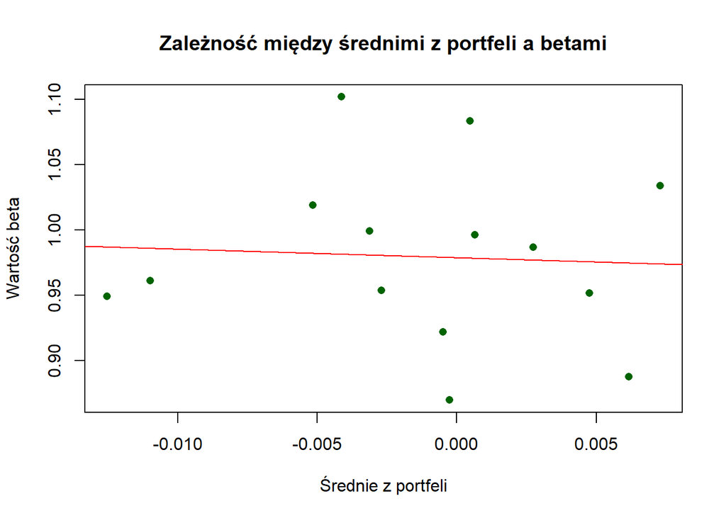

```r
srednie_portfeli <- colMeans(zmienne[,-15])
beta <- alfa_beta$beta
trend_model <- lm(beta ~ srednie_portfeli)

plot(srednie_portfeli, beta,
     xlab = "Średnie z portfeli",
     ylab = "Wartość beta",
     main = "Zależność między średnimi z portfeli a betami",
     col = "darkgreen",
     pch = 16)

# Dodanie linii trendu
abline(trend_model, col = "red")
```

Linia trendu jest prawie stała, a wyznaczone punkty są rozproszone, oznacza to, że istnieje niewielka lub brak zależności między średnimi z portfeli a wartościami beta.

# Weryfikacja modelu

## Istotność poszczególnych zmiennych

Za pomocą testu t sprawdzono istnotność poszczególnych zmiennych.

*H0: zmienna jest nieistotna*  
*H1: zmienna jest istotna*

Tabela przedstawia otrzymane wartości p-value.

```r
p_alpha0 <- c()
p_alpha1 <- c()

p_alpha0[10] = summary(mnk[[10]])$coefficients[1,4]

for(i in 1:length(mnk)){
  p_alpha0[i] = summary(mnk[[i]])$coefficients[1,4]
  p_alpha1[i] = summary(mnk[[i]])$coefficients[2,4]
}

p_value <- data.frame(indeksy = (colnames(zmienne)[-1]), p_value_a0 = p_alpha0, p_value_a1 = p_alpha1)
knitr::kable(p_value, align = "cccc")
```

| indeksy | p_value_a0 | p_value_a1 |
| --- | --- | --- |
| wig_banki | 0.3868325 | 0 |
| wig_budow | 0.2034370 | 0 |
| wig_chemia | 0.3182084 | 0 |
| wig_energia | 0.8635555 | 0 |
| wig_gornic | 0.7988987 | 0 |
| wig_gry | 0.4651774 | 0 |
| wig_info | 0.5719511 | 0 |
| wig_leki | 0.3861470 | 0 |
| wig_media | 0.7002223 | 0 |
| wig_moto | 0.7385206 | 0 |
| wig_nrchom | 0.5353443 | 0 |
| wig_odziez | 0.2725867 | 0 |
| wig_paliwa | 0.9604886 | 0 |
| wig_spozyw | 0.0417359 | 0 |

Analizując powyższą tabelę, zauważono, że prawie wszystkie wartości p p-value dla wyrazów wolnych w poszczególnych równaniach są większe niż 0.05. Wynika z tego, że nie mamy podstaw do odrzucenia hipotezy zerowej (H0), co sugeruje, że te wyrazy są nieistotne.

Aby dalej zweryfikować, czy wszystkie wyrazy wolne w modelu są łącznie nieistotne, przeprowadzono test restrykcji znany jako test GRS (Gibbons, Ross, Shanken). W celu przeprowadzenia tego testu konieczne jest wyznaczenie reszt oraz ich macierzy wariancji-kowariancji z naszego modelu.

```r
reszty <- matrix(NA, nrow(zmienne), ncol(zmienne)-1)

for(i in 1:nrow(reszty)){
  for(j in 1:length(mnk)){
    reszty[i,j] <- mnk[[j]]$residuals[i]
  }
}

MacierzReszt <- data.frame(reszty)
```

## Test restrykcji GRS

Test GRS umożliwia sprawdzenie, czy wyrazy wolne z modeli regresji są statystycznie łącznie różne od zera w ramach grupy portfeli, a zatem hipotezy testu przedstawiają się w sposób następujący:

*H0:* $\alpha_i = 0$

*H1:* $\alpha_i \neq 0$ dla $i = 1, 2, ..., N$

Statystykę GRS natomiast prezentuje wzór:

$$GRS =
(\frac{T}{N})(\frac{T-N-K}{T-K-1})(\frac{\hat\alpha^T\hat\Sigma^{-1}\hat\alpha}{1+\hat\mu^T\hat{V}^{-1}\hat\mu})$$
gdzie:

$T$ - liczebność próby (85),

$N$ - liczba portfeli objaśnianych w badanej grupie (14),

$K$- liczba czynników ryzyka (objaśniających) (1),

$\hat\alpha_i$ - wektor wyrazów wolnych z regresji,

$\hat\Sigma$ - estymator macierzy wariancji-kowariancji składników losowych,

$\hat\mu$ - średnia czynnika ryzyka (WIGu),

$\hat{V}$ - wariancja czynnika ryzyka (WIGu).

Statystyka ma rozkład Fishera z oraz $N$ oraz $T - N - K$ stopniami swobody.

```r
SIGMA <- cov(MacierzReszt)
VarianceWIG <- var(zmienne[, -1])
MeanWIG <- colMeans(zmienne[, -1])

T <- nrow(zmienne)
N <- ncol(zmienne) - 1
K <- 1

GRS <- (T/N)*((T-N-K)/(T-K-1)) *
  (t(alfa)%*%(SIGMA)^(-1)%*%alfa)/((1+t(MeanWIG)%*%(VarianceWIG)^(-1)%*%MeanWIG))
Fkryt = qf(0.95, N, T-N-K)
```

Uzyskane wyniki statystyk:

```r
grs <- data.frame(Wartosc_GRS = GRS, Wartosc_krytyczna = Fkryt)
knitr::kable(grs, align = "cc")
```

| Wartosc_GRS | Wartosc_krytyczna |
| --- | --- |
| 1.63053 | 1.835683 |

Uzyskana wartość statystyki GRS jest mniejsza od wartości krytycznej, zatem nie istnieją podstawy do odrzucenia hipotezy zerowej testu - wektor $\alpha_i$ parametrów jest nieistotny.

## UMNK

Jest to technika, która dąży do minimalizacji sumy kwadratów różnic między wartościami obserwowanymi a wartościami przewidywanymi przez model.

Wyestymowno parametry ${\beta}$ metodą UMNK

$$\hat{\beta}_{UMNK} = (X^T \Sigma^{-1}
X)^{-1} X^T \Sigma^{-1} Y$$

Gdzie:

$\hat{\beta}_{UMNK}$ - oznacza estymator UMNK dla wektora parametrów,

$X$ to macierz zmiennych objaśniających,

$\Sigma$ to macierz korelacji zmiennych objaśniających,

$Y$ to wektor zmiennej objaśnianej.

```r
X <- as.matrix(zmienne[,-1])
Y <- as.matrix(zmienne[,1])
Sigma <- cor(X)
# macierz odwrotna do sigmy
Sigma_odw <- solve(Sigma)
beta_UMNK <- (t(X)%*%X%*%Sigma_odw)^(-1) %*% (t(X%*%Sigma_odw)%*%Y)
knitr::kable(beta_UMNK, align = "cccc")
```

| wig_banki | 8.162161 |
| --- | --- |
| wig_budow | 9.783426 |
| wig_chemia | 9.842434 |
| wig_energia | 10.488770 |
| wig_gornic | 9.499355 |
| wig_gry | 8.026142 |
| wig_info | 11.686968 |
| wig_leki | 10.237149 |
| wig_media | 9.994283 |
| wig_moto | 9.743562 |
| wig_nrchom | 13.755109 |
| wig_odziez | 10.405345 |
| wig_paliwa | 12.813719 |
| wig_spozyw | 9.360119 |

Wykres przedstawiający zależność między średnimi z portfeli, a betami:

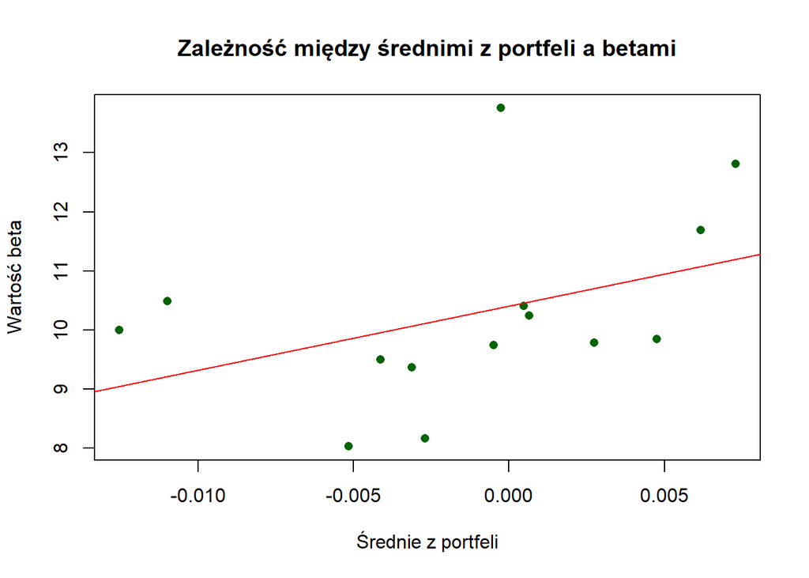

```r
srednie_portfeli <- colMeans(zmienne[,-15])
beta <- beta_UMNK
trend_model <- lm(beta ~ srednie_portfeli)

plot(srednie_portfeli, beta,
     xlab = "Średnie z portfeli",
     ylab = "Wartość beta",
     main = "Zależność między średnimi z portfeli a betami",
     col = "darkgreen",
     pch = 16)

# Dodanie linii trendu
abline(trend_model, col = "red")
```